# 09_Comparison.prot_Sonnett2018_&_VanItallie.2021

Author

Andrea Mariossi

Published

December 1, 2023

# 1 Frog proteomes times series

We scale the proteome data so that the sum of each protein’s values across time points integrates to 1 before comparing the datasets.

## 1.1 Sonnett et al. 2018

## 1.2 Van Itallie et al. 2021

This data have already been normalized by the 11 channel. The row sum is 11.

There are 3 biological replicates for each stage.

```
# A tibble: 6 × 38
  Protein_Reference laevisGeneName human humanGene description Chan_1_17
  <chr>             <chr>          <chr> <chr>     <chr>           <dbl>
1 MT-ATP6|MT-ATP6   MT-ATP6        <NA>  MT-ATP6   <NA>            0.066
2 MT-CO1|MT-CO1     MT-CO1         <NA>  MT-CO1    <NA>            0.136
3 MT-CO2|MT-CO2     MT-CO2         <NA>  MT-CO2    <NA>            0.1
4 MT-CYB|MT-CYB     MT-CYB         <NA>  MT-CYB    <NA>            0.049
5 MT-ND1|MT-ND1     MT-ND1         <NA>  MT-ND1    <NA>            0.122
6 MT-ND2|MT-ND2     MT-ND2         <NA>  MT-ND2    <NA>            0.124
# ℹ 32 more variables: Chan_2_17 <dbl>, Chan_3_17 <dbl>, Chan_4_17 <dbl>,
#   Chan_5_17 <dbl>, Chan_6_17 <dbl>, Chan_7_17 <dbl>, Chan_8_17 <dbl>,
#   Chan_9_17 <dbl>, Chan_10_17 <dbl>, Chan_11_17 <dbl>, Chan_1_18 <dbl>,
#   Chan_3_18 <dbl>, Chan_2_18 <dbl>, Chan_4_18 <dbl>, Chan_5_18 <dbl>,
#   Chan_6_18 <dbl>, Chan_7_18 <dbl>, Chan_8_18 <dbl>, Chan_9_18 <dbl>,
#   Chan_10_18 <dbl>, Chan_11_18 <dbl>, Chan_1_22 <dbl>, Chan_2_22 <dbl>,
#   Chan_3_22 <dbl>, Chan_4_22 <dbl>, Chan_5_22 <dbl>, Chan_6_22 <dbl>, …
```

```
rowSum_tot
    1
16716
```

```
rowSum_tot
   11
16716
```

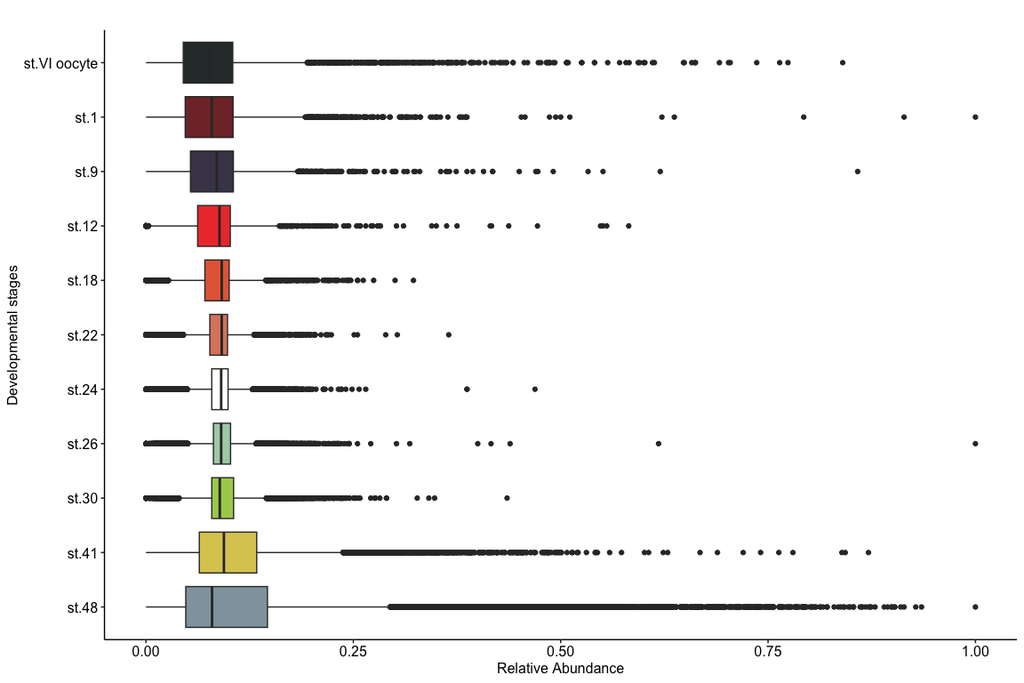

### 1.2.1 Checking the replicates correlations

maybe drop biological replicate 3?

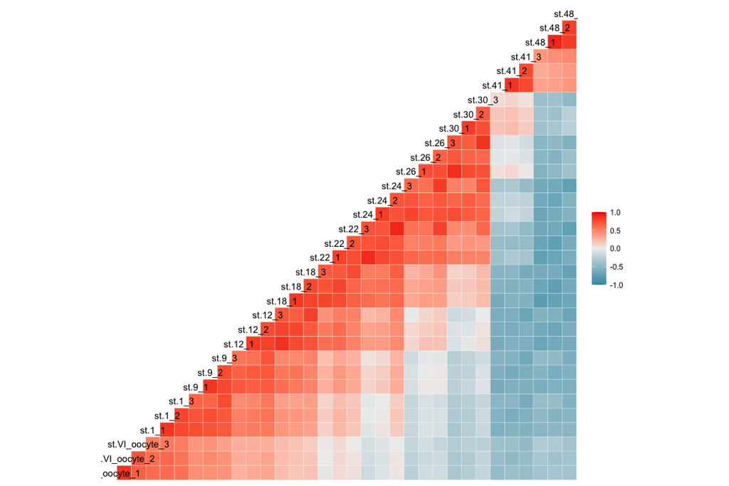

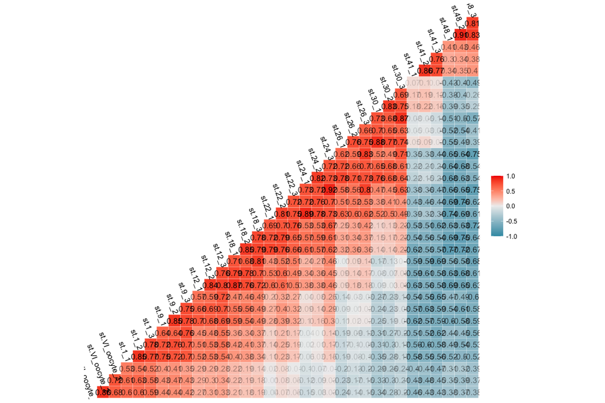

### 1.2.2 K-means protein dynamics

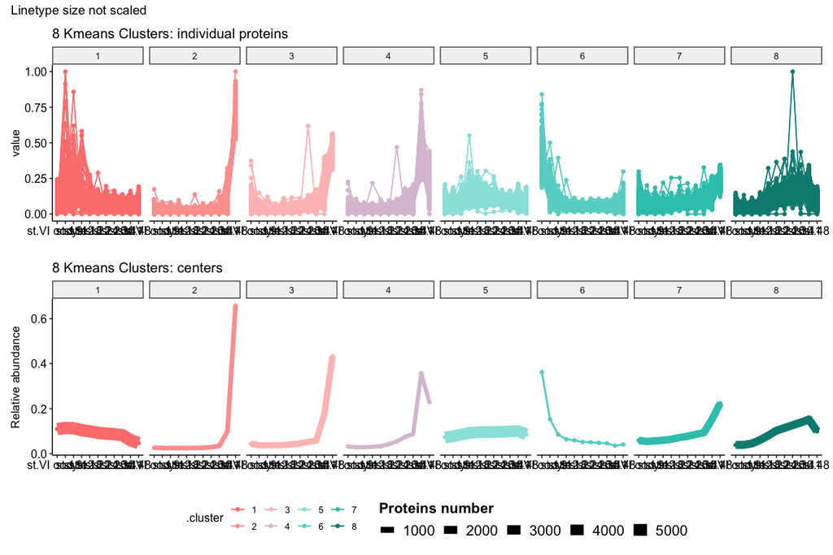

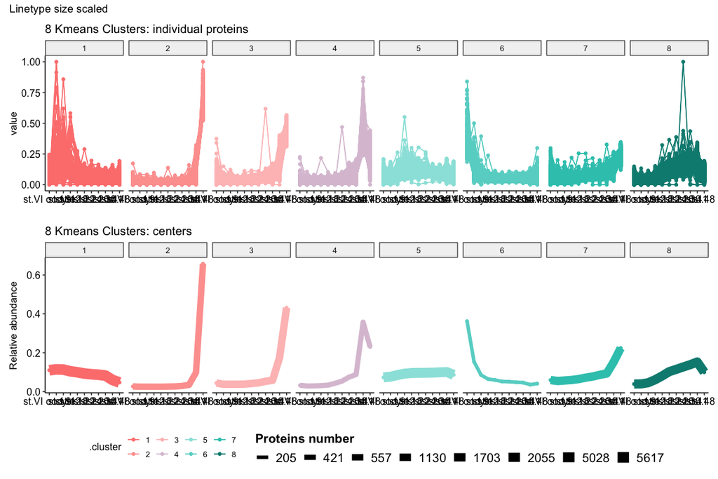

## 1.3 Matching genome annotation

To match the different annotation versions (XenLa 9.2 to 10.1), we used reciprocal BLASTp.

A reciprocal BLAST is performed by running BLASTp with the first species protein file as the “query” and the second species as the “db”. The reciprocal BLAST is completed by switching the species as query and db inputs.

### 1.3.1 Reciprocal Best Hit (RBH) from BLASTp search

Performing BLAST alignments of query->target and target->query

### 1.3.2 Find Reciprocal Best Hits (RBH)

Reciprocal best BLAST hits are those where the best match for any given query sequence in the query->target alignment is also the best hit of the match in the reverse (target->query) alignment.

The column header of BLAST results are:

1. qseqid query or source (gene) sequence id
2. sseqid subject or target (reference genome) sequence id
3. pident percentage of identical positions
4. length alignment length (sequence overlap)
5. mismatch number of mismatches
6. gapopen number of gap openings
7. qstart start of alignment in query
8. qend end of alignment in query
9. sstart start of alignment in subject
10. send end of alignment in subject
11. evalue expect value
12. bitscore bit score

```
# A tibble: 6 × 3
# Groups:   queryId [6]
  queryId        subjectId bitscore
  <chr>          <chr>        <dbl>
1 XBXL10_1g1     gene34907      644
2 XBXL10_1g1000  gene37670     1544
3 XBXL10_1g10000 gene15467      207
4 XBXL10_1g10001 gene49282     1090
5 XBXL10_1g10002 gene75         600
6 XBXL10_1g10005 gene17527      380
```

```
     queryHits       dbHits bestHits
1 v9.2_to_10.1 v10.1_to_9.2   common
2        41702        60166    28914
```

### 1.3.3 RBH same as before - probably slight faster

```
[1] TRUE
```

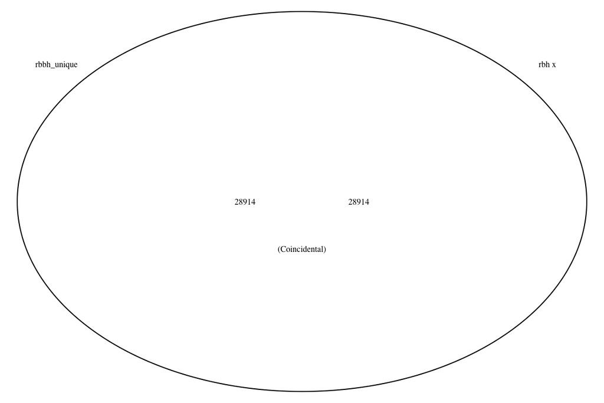

### 1.3.4 0-1

## 1.4 Comparison of the 2 proteosomes time series

```
      st.VI oocyte        st.1        st.9      st.12      st.18       st.22
St.1    0.74769245  0.82633301  0.60849459  0.3928588  0.1446850 -0.19036547
St.2    0.71337262  0.81528207  0.69448880  0.4655217  0.2008059 -0.14128455
St.8    0.58904454  0.74761667  0.78597587  0.5573146  0.2976185 -0.06674170
St.10   0.52539155  0.69422681  0.83650772  0.6740977  0.3958536  0.01040642
St.12   0.36386107  0.48537047  0.68685242  0.8014370  0.6032303  0.22291527
St.17   0.04565652  0.08884917  0.24349894  0.6431363  0.7309865  0.56877255
St.20  -0.20479928 -0.21242224 -0.08441642  0.3056924  0.5635802  0.64522476
St.25  -0.46654077 -0.54540135 -0.49543615 -0.2002962  0.1661821  0.51066881
St.30  -0.55268625 -0.67705522 -0.68745712 -0.6076199 -0.3812899  0.02655627
St.35  -0.52498633 -0.64772140 -0.70519783 -0.7566187 -0.6463800 -0.34496245
            st.24       st.26      st.30      st.41       st.48
St.1  -0.38953531 -0.53137277 -0.6170696 -0.5761566 -0.38422134
St.2  -0.36468713 -0.53443255 -0.6383009 -0.6139692 -0.41555763
St.8  -0.30114835 -0.48655033 -0.6118885 -0.6331512 -0.44205868
St.10 -0.25635159 -0.47383703 -0.6070451 -0.6658268 -0.47220359
St.12 -0.06408068 -0.33358812 -0.4819274 -0.6411257 -0.49055571
St.17  0.33154804  0.04120153 -0.1149650 -0.4564859 -0.41586724
St.20  0.53306306  0.31545437  0.2070667 -0.1920660 -0.25617658
St.25  0.62012553  0.58940860  0.5629651  0.1972047  0.04673007
St.30  0.31131335  0.54999451  0.6541812  0.5794729  0.39870922
St.35 -0.05199535  0.26256228  0.4624551  0.7956090  0.63341266
```

```
      st.VI oocyte        st.1       st.9       st.12        st.18       st.22
St.1     0.7894329  0.83066139  0.7095166  0.48256397  0.213684954 -0.20648001
St.2     0.7796938  0.83898631  0.7444500  0.51856230  0.243139535 -0.17135303
St.8     0.7508106  0.82728614  0.7960720  0.58543430  0.318669552 -0.13727829
St.10    0.6806974  0.77458331  0.8252065  0.66595279  0.384418885 -0.07646407
St.12    0.4544762  0.52624235  0.6590106  0.69923982  0.506079752  0.07765657
St.17    0.0468866  0.07055928  0.1989690  0.43046213  0.548537730  0.41852285
St.20   -0.2801714 -0.26309790 -0.1552810  0.09490931  0.323060936  0.50426318
St.25   -0.5560279 -0.59895134 -0.5321404 -0.30840274 -0.004812326  0.41172835
St.30   -0.6614700 -0.75459718 -0.7257582 -0.57546913 -0.318038031  0.10853884
St.35   -0.7164552 -0.81554919 -0.8199277 -0.71551796 -0.485432172 -0.01711086
           st.24       st.26       st.30       st.41        st.48
St.1  -0.4331589 -0.56971597 -0.67137768 -0.67865726 -0.480517430
St.2  -0.4154201 -0.56641544 -0.67550613 -0.70149819 -0.509439752
St.8  -0.3905135 -0.55612487 -0.67599517 -0.72883791 -0.529933916
St.10 -0.3638025 -0.54365856 -0.66301428 -0.72788556 -0.536663743
St.12 -0.1900271 -0.37622662 -0.47601742 -0.59249296 -0.434502964
St.17  0.2417745  0.07094983 -0.02392441 -0.24848124 -0.233924138
St.20  0.4720986  0.35307344  0.32582467  0.08976262 -0.004004732
St.25  0.5988418  0.63499298  0.64126643  0.44490597  0.270969654
St.30  0.3832686  0.57742198  0.68509558  0.69134059  0.514522743
St.35  0.2899439  0.52418018  0.67796303  0.83746359  0.635842442
```

## 1.5 Heatmap frog proteome time series

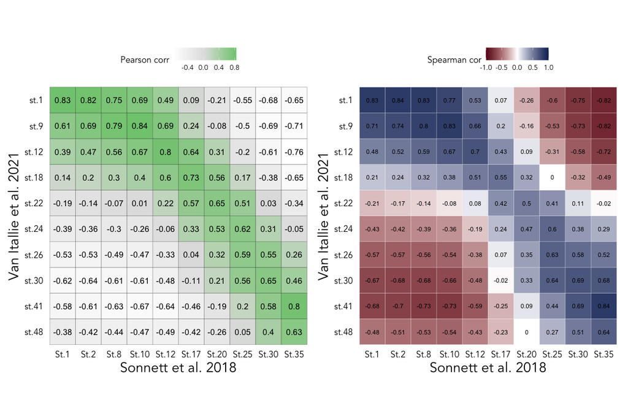